# Applied Multivariate: Identifying differences between groups

```r
library(vegan)
library(gridExtra)
library(tidyverse)
```

## Linear discriminant analysis

- Often we have groups that we have defined *a priori* before doing an analysis and we seek to understand what makes those groups different
- Linear discrimination analysis (LDA), similar to multinomial logistic regression, attempts to find linear combinations of variables that best separate groups when predicting two or more dependent variables, using continuous independent variables.

### Load the data

We will use the data set `morph_data.csv` on github. The data consisted of 8 measurements in all 5 larval stages and the adults of the 6 species of the waterstrider genus Limnoporus (Insecta: Heteroptera: Gerridae). Data was originally sourced from [morphometry datasets](http://life.bio.sunysb.edu/morph/data/datasets.html).

The variables are: Species, stage (1-5 for larvae, 6 for adults), sex (m male, f female, u undetermined), antseg1 - antseg4 (lengths of 1st to 4th antennal segments), midfem, midtib, hindfem, hindtib (lenghts of middle and hind femora and tibiae). The values are raw measurements in millimeters.

```r
morph_data <-read_csv("https://raw.githubusercontent.com/chrischizinski/SNR_R_Group/master/data/morph_data.csv")
glimpse(morph_data)
```

```
Observations: 541
Variables: 11
$ Species <chr> "canali", "canali", "canali", "canali", "canali", "canali", "canali", "canali", "canali", "canali", "c...
$ stage   <int> 1, 1, 1, 1, 1, 1, 1, 1, 1, 1, 2, 2, 2, 2, 2, 2, 2, 2, 2, 2, 3, 3, 3, 3, 3, 3, 3, 3, 3, 3, 4, 4, 4, 4, ...
$ sex     <chr> "u", "u", "u", "u", "u", "u", "u", "u", "u", "u", "u", "u", "u", "u", "u", "u", "u", "u", "u", "u", "u...
$ antseg1 <dbl> 0.17, 0.20, 0.18, 0.16, 0.13, 0.18, 0.18, 0.18, 0.20, 0.16, 0.32, 0.28, 0.30, 0.24, 0.26, 0.23, 0.26, ...
$ antseg2 <dbl> 0.15, 0.14, 0.14, 0.13, 0.13, 0.16, 0.12, 0.15, 0.15, 0.14, 0.24, 0.24, 0.20, 0.22, 0.22, 0.20, 0.20, ...
$ antseg3 <dbl> 0.19, 0.18, 0.17, 0.14, 0.16, 0.18, 0.16, 0.16, 0.19, 0.18, 0.28, 0.29, 0.22, 0.27, 0.26, 0.24, 0.26, ...
$ antseg4 <dbl> 0.72, 0.74, 0.62, 0.55, 0.56, 0.52, 0.72, 0.60, 0.67, 0.60, 0.80, 0.74, 0.70, 0.70, 0.72, 0.74, 0.75, ...
$ midfem  <dbl> 0.70, 0.76, 0.76, 0.70, 0.72, 0.76, 0.74, 0.76, 0.78, 0.80, 1.08, 1.16, 1.22, 1.12, 1.16, 1.00, 1.04, ...
$ midtib  <dbl> 0.80, 0.92, 0.94, 0.92, 0.92, 0.97, 0.91, 0.92, 0.95, 0.98, 1.36, 1.36, 1.26, 1.22, 1.30, 1.26, 1.28, ...
$ hindfem <dbl> 0.43, 0.68, 0.79, 0.74, 0.68, 0.68, 0.70, 0.70, 0.78, 0.73, 1.16, 1.25, 1.15, 1.18, 1.15, 1.06, 1.10, ...
$ hindtib <dbl> 0.72, 0.42, 0.40, 0.42, 0.38, 0.45, 0.42, 0.43, 0.44, 0.44, 0.58, 0.56, 0.54, 0.58, 0.56, 0.50, 0.56, ...
```

### Manipulate the data

For the purpose of this excercise lets limit the data to one species and only the measurements of the antennae.

```r
morph_data %>%
  select(Species:antseg4, -sex) %>%
  filter(Species == "canali") %>%
  mutate_at(vars(antseg1:antseg4), scale)-> canal_data
head(canal_data)
```

| Species | stage | antseg1 | antseg2 | antseg3 | antseg4 |
| --- | --- | --- | --- | --- | --- |
| canali | 1 | -1.314840 | -1.334497 | -1.382457 | -1.270876 |
| canali | 1 | -1.258668 | -1.362171 | -1.415054 | -1.222878 |
| canali | 1 | -1.296116 | -1.362171 | -1.447650 | -1.510865 |
| canali | 1 | -1.333564 | -1.389845 | -1.545440 | -1.678858 |
| canali | 1 | -1.389736 | -1.389845 | -1.480247 | -1.654859 |
| canali | 1 | -1.296116 | -1.306823 | -1.415054 | -1.750854 |

### Conduct the linear discriminant analysis using `MASS::lda()`

```r
canal_lda<-MASS::lda(stage~antseg1 + antseg2 + antseg3 + antseg4, data = canal_data)
canal_lda
```

```
Call:
lda(stage ~ antseg1 + antseg2 + antseg3 + antseg4, data = canal_data)

Prior probabilities of groups:
        1         2         3         4         5         6
0.1111111 0.1111111 0.1111111 0.2222222 0.2222222 0.2222222

Group means:
     antseg1    antseg2    antseg3    antseg4
1 -1.3073501 -1.3594034 -1.4443907 -1.4868663
2 -1.1332171 -1.1490818 -1.1510214 -1.2348777
3 -0.8167818 -0.8640406 -0.8315750 -0.9156920
4 -0.3028084 -0.2399942 -0.1731241 -0.0805297
5  0.4283631  0.5487119  0.6043044  0.6886356
6  1.5031198  1.3775452  1.2823132  1.2106121

Coefficients of linear discriminants:
               LD1        LD2        LD3       LD4
antseg1 14.5047455 -7.2205800  3.8168030  2.764369
antseg2 -3.8449898  1.2049129 -8.6374675 -2.428811
antseg3 -1.7878986  0.9023135  4.3236873 -3.984543
antseg4 -0.2461576  5.5171016  0.5203163  3.569601

Proportion of trace:
   LD1    LD2    LD3    LD4
0.9719 0.0276 0.0003 0.0002
```

```r
names(canal_lda)
```

```
 [1] "prior"   "counts"  "means"   "scaling" "lev"     "svd"     "N"       "call"    "terms"   "xlevels"
```

### Explanation of the output

#### Prior

From the raw data, the break down in proportions of the number of individuals in each group

```r
canal_lda$prior
```

```
        1         2         3         4         5         6
0.1111111 0.1111111 0.1111111 0.2222222 0.2222222 0.2222222
```

#### Group means

The mean value for each of the variables for each group

```r
canal_lda$means
```

```
     antseg1    antseg2    antseg3    antseg4
1 -1.3073501 -1.3594034 -1.4443907 -1.4868663
2 -1.1332171 -1.1490818 -1.1510214 -1.2348777
3 -0.8167818 -0.8640406 -0.8315750 -0.9156920
4 -0.3028084 -0.2399942 -0.1731241 -0.0805297
5  0.4283631  0.5487119  0.6043044  0.6886356
6  1.5031198  1.3775452  1.2823132  1.2106121
```

#### Coefficients

```r
canal_lda$scaling
```

```
               LD1        LD2        LD3       LD4
antseg1 14.5047455 -7.2205800  3.8168030  2.764369
antseg2 -3.8449898  1.2049129 -8.6374675 -2.428811
antseg3 -1.7878986  0.9023135  4.3236873 -3.984543
antseg4 -0.2461576  5.5171016  0.5203163  3.569601
```

You can also standardize the coefficients (loadings), which provides the relative strength of each factor on linear discriminant analysis

```r
loadings <-canal_lda$scaling
col.ss <- colSums(loadings^2)
sweep(loadings,2,sqrt(col.ss),"/")
```

```
                LD1         LD2         LD3        LD4
antseg1  0.95969829 -0.78391461  0.36703621  0.4257438
antseg2 -0.25440157  0.13081342 -0.83060701 -0.3740641
antseg3 -0.11829530  0.09796121  0.41577985 -0.6136643
antseg4 -0.01628688  0.59897356  0.05003531  0.5497585
```

### Variation expained

The amount of variation explained by the each of the linear discriminant axis

```r
prop = canal_lda$svd^2/sum(canal_lda$svd^2)
prop
```

```
[1] 0.9719389713 0.0275790703 0.0003069345 0.0001750239
```

### Graphing the results

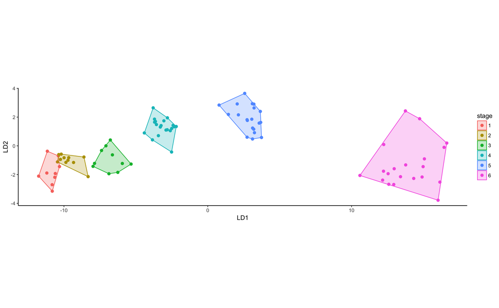

```r
# extracting the data
lda_pred <- predict(canal_lda)
lda_scores<-data.frame(stage = lda_pred$class, lda_pred$x)
#developing hulls for each stage group
hull1<- lda_scores[lda_scores$stage ==1,][chull(lda_scores[lda_scores$stage ==1,c("LD1", "LD2")]),]
hull2<- lda_scores[lda_scores$stage ==2,][chull(lda_scores[lda_scores$stage ==2,c("LD1", "LD2")]),]
hull3<- lda_scores[lda_scores$stage ==3,][chull(lda_scores[lda_scores$stage ==3,c("LD1", "LD2")]),]
hull4<- lda_scores[lda_scores$stage ==4,][chull(lda_scores[lda_scores$stage ==4,c("LD1", "LD2")]),]
hull5<- lda_scores[lda_scores$stage ==5,][chull(lda_scores[lda_scores$stage ==5,c("LD1", "LD2")]),]
hull6<- lda_scores[lda_scores$stage ==6,][chull(lda_scores[lda_scores$stage ==6,c("LD1", "LD2")]),]
all_hulls <- rbind(hull1, hull2, hull3, hull4, hull5, hull6)
#plot using gglot2
ggplot(data = lda_scores) +
  geom_point(aes(x = LD1, y = LD2, color = stage), size = 2) +
  geom_polygon(data = all_hulls,aes(x = LD1, y = LD2, color = stage, fill = stage), alpha = 0.25) +
  coord_equal() +
  theme_classic()
```

### Assessing the accuracy of the predicitions

```r
ct <- table(canal_data$stage, lda_pred$class)
ct
```

```
     1  2  3  4  5  6
  1  9  1  0  0  0  0
  2  0 10  0  0  0  0
  3  0  0 10  0  0  0
  4  0  0  0 20  0  0
  5  0  0  0  0 20  0
  6  0  0  0  0  0 20
```

```r
# percent correct for each stage
diag(prop.table(ct, 1))
```

```
  1   2   3   4   5   6
0.9 1.0 1.0 1.0 1.0 1.0
```

```r
# total percent correct
sum(diag(prop.table(ct)))
```

```
[1] 0.9888889
```